# 2 Red Card Study

## 2.1 Loading and cleaning the data

In the first part of the exercise, we load and explore the dataset. Then, we clean it by excluding datapoints with missing values and only keeping relevant features. Note that the data comes in the format of player / referee pairs ('dyad'). Hence one row contains the data about the interactions between a single player and a single referee. Note that this part of the exercise is pretty open ended, hence there are a number of viable choices here.

```python
import numpy as np
import pandas as pd
import matplotlib.pyplot as plt
```

```python
# load the data from file as pandas DataFrame
data = original_data = pd.read_csv("CrowdstormingDataJuly1st.csv")

# look at the data format
print("Shape of the raw data:", data.shape)
print("Columns (Features) of the raw data:", data.axes[1])
```

```
Shape of the raw data: (146028, 28)
Columns (Features) of the raw data: Index(['playerShort', 'player', 'club', 'leagueCountry', 'birthday', 'height',
       'weight', 'position', 'games', 'victories', 'ties', 'defeats', 'goals',
       'yellowCards', 'yellowReds', 'redCards', 'photoID', 'rater1', 'rater2',
       'refNum', 'refCountry', 'Alpha_3', 'meanIAT', 'nIAT', 'seIAT',
       'meanExp', 'nExp', 'seExp'],
      dtype='object')
```

First, we exclude all pairs, for which no photo and hence no skin rating is present, as this information is crucial for the problem.

```python
mask = pd.notnull(data['photoID'])
print("Number of missing photo IDs", data.shape[0] - np.sum(mask))
# drop rows with missing ids:
data = data.loc[mask]
# make sure that all players have skin ratings, now that we have dropped missing photo ids
assert np.sum( pd.isnull( data['rater1'] ) ) == 0
assert np.sum( pd.isnull( data['rater2'] ) ) == 0
```

```
Number of missing photo IDs 21407
```

Also note that the number of unique 'player's and 'playerShort's does not agree. This is due to the fact the names of the player are not unequivocal! Therefore we have to use playerShort as a unique identifier for each player.

```python
print("Number of unique playerShorts:", np.unique(data['playerShort']).shape)
print("Number of unique players:", np.unique(data['player']).shape)
```

```
Number of unique playerShorts: (1585,)
Number of unique players: (1572,)
```

Next we drop the irrelevant features from the dataset. Note that which features are relevant is mostly debatable. Here is the list of features we drop and our reasoning for this:

- 'photoID': Obviously this holds no relevant information.
- 'meanIAT', 'nIAT', 'seIAT', 'meanExp', 'nExp', 'seExp': These values stand for racial biases in the referee coutries, however they are only relevant for the second question of the original study and hence of no interest for our problem.
- 'yellowCards': We are only interested in the number of red cards. (One could of course repeat the whole exercise for yellow cards, but we wont do this here).
- 'Alpha_3': These are the abbreviations for the refery countrys and hence redundant. Note that here at least the number of unique values is consistent:

```python
print("Number of unique refCountrys:", np.unique(data['refCountry']).shape)
print("Number of unique Alpha_3s:", len(data['Alpha_3'].unique()))
#print("Number of unique Alpha_3s:", np.unique(data['Alpha_3']).shape)  <-- works only in python 2
```

```
Number of unique refCountrys: (160,)
Number of unique Alpha_3s: 160
```

```python
# construct dataset with only the features that seem (definetly) relevant
irrelevant_feats = ['photoID', 'Alpha_3', 'yellowCards',
                    'meanIAT', 'nIAT', 'nIAT', 'seIAT', 'meanExp', 'nExp', 'seExp', 'refNum', 'refCountry']
data = data.drop(irrelevant_feats, axis = 1)
print("Shape of dataset after dropping irrelevant features:", data.shape)
```

```
Shape of dataset after dropping irrelevant features: (124621, 17)
```

Next, we will exclude all rows with missing values from our cleaned dataset.

```python
data.dropna(axis = 0, inplace = True)
print("Shape of dataset after dropping missing values:", data.shape)
```

```
Shape of dataset after dropping missing values: (115603, 17)
```

Since we are only interested in the Number of Cards per player, regardless of the referee, we have to sum over all rows corresponding to the same player, while keeping entry independent values (such as club, birthday, etc.) constant:

```python
gdata = data.groupby(['playerShort'])
variable_features = ['games', 'victories', 'ties', 'defeats', 'goals', 'yellowReds', 'redCards']
static_features = ['playerShort', 'player', 'club', 'leagueCountry', 'birthday', 'height', 'weight', 'position', 'rater1', 'rater2']
variable_data = gdata[variable_features].sum()
static_data = data[static_features]
static_data = static_data.drop_duplicates()

aggregated_data = variable_data.join(static_data.set_index('playerShort'), on='playerShort')
```

Next, we construct features and targets from the datset. For the features, we need to make some adjustments:

- We convert the 'birthday' to the players age, taking the 1st of July 2015 (publication date of the csv-file) as reference date.
- For the categorical features, we create two different representations: An ordinal one (introducing an arbitrary order of the categories) and a 1 of n vectorial representation. Note that both of these strategies have their problems. The arbitrary order in the first strategy may lead to artifacts in the results. The second strategy leads to a very high dimensional feature space for a categorical feature with many different unique labels.
- We take the mean of the two skincolor ratings. (Here one could probably come up with more clever ways for disagreeing ratings).

For the target vector, we add up the number of red and yellow-red cards for each player and divide it by the number of games.

```python
prediction_data = aggregated_data.copy()
```

```python
del data
```

```python
prediction_data['rating'] = (prediction_data.loc[:,'rater1'] + prediction_data.loc[:,'rater2']) / 2
prediction_data.drop(['rater1', 'rater2'], axis = 1, inplace = True)
```

```python
# construct the feature matrices

# 3 of the columns in our dataframe are used to construct the target, note that we still leave game as a variable
# - this is of course also debatable.
# and 2 of the columns are combined to one feature
# another one is the original player name which we don't need either
# -> we have 11 features

class myDataset:
    def __init__(self, data):
        self.data = data
        self.ordinal_feats = ['rating', 'height', 'weight', 'games', 'victories',
                              'ties', 'defeats', 'goals', 'birthday']
        self.ordinal_feats = list(set(self.ordinal_feats) & set(data.columns))

        self.categorical_feats = ['player', 'club', 'leagueCountry', 'position']
        self.categorical_feats = list(set(self.categorical_feats) & set(data.columns))

        self.n_ord = len(self.ordinal_feats)
        self.n_cat = len(self.categorical_feats)
        self.n_onehot = np.sum([len(data.loc[:, feat].unique()) for feat in self.categorical_feats])
        self.X_ordinal, self.X_catord, self.targets = self.construct_features()

    def construct_features(self):
        X_ordinal = np.zeros( (self.data.shape[0], self.n_ord) )

        for i, feat in enumerate(self.ordinal_feats):
            if feat != 'birthday':
                X_ordinal[:,i] = self.data.loc[:, feat]

            else:
                #birthday -> age
                ref_day   = 1
                ref_month = 7
                ref_year  = 2015

                bds = np.array(self.data.loc[:,'birthday'] )
                for j in range(self.data.shape[0]):
                    # this can be done in a more elegant way probably...
                    bd = bds[i]
                    bd_split = bd.split('.')
                    day   = int(bd_split[0])
                    month = int(bd_split[1])
                    year  = int(bd_split[2])
                    if month < ref_month and day < ref_day:
                        X_ordinal[j,i] = ref_year - year - 1
                    else:
                        X_ordinal[j,i] = ref_year - year

        # categorical features to order
        X_catord = np.zeros((self.data.shape[0], self.n_cat))
        for i, feat in enumerate(self.categorical_feats):
            X_catord[:,i]  = self.categorical_to_ordinal(feat)

        # construct the target vector by adding up red and yellow red cards and divide by number of games
        targets = np.array( (self.data.loc[:,'redCards'] + self.data.loc[:,'yellowReds']) / self.data.loc[:, 'games'])

        return X_ordinal, X_catord, targets

    def categorical_to_ordinal(self, cat_label):
            cat_feats   = np.array( self.data.loc[:,cat_label] )
            unique_labs = np.unique(cat_feats)
            labs_to_order = {}
            for i in range(unique_labs.shape[0]):
                labs_to_order[unique_labs[i]] = i
            X = np.zeros(self.data.shape[0])
            for i in range(self.data.shape[0]):
                X[i] = labs_to_order[cat_feats[i]]
            assert np.unique(X).shape == unique_labs.shape
            return X

    def categorical_to_onehot(self, cat_label):
        cat_feats   = np.array( self.data.loc[:,cat_label] )
        unique_labs = np.unique(cat_feats)
        X = np.zeros( (self.data.shape[0], unique_labs.shape[0]) )
        labs_to_pos = {}
        for i in range(unique_labs.shape[0]):
            labs_to_pos[unique_labs[i]] = i
        for i in range(self.data.shape[0]):
            pos = labs_to_pos[cat_feats[i]]
            X[i,pos] = 1
        return X

    # construct different feature sets (first letters show the abbreviations we'll use):
    # - oc:  the ordinal and categorical to ordinal features
    # - on:  all ordinal and onehot representation features
    # - oc_: ordinal + categorical to ordinal features, normalized
    # - onr_:ordinal (normalized) + onehot representations of low dimension
    # we write generator functions for these features, otherwise this computes too much memory!
    # data, X_ordinal, X_catord = construct_features(data)

    def get_X_oc(self):
        X_oc = np.zeros( (self.data.shape[0], self.n_ord + self.n_cat))
        X_oc[:,:self.n_ord] = self.X_ordinal
        X_oc[:,self.n_ord:] = self.X_catord
        return X_oc

    def get_X_on(self):
        X_on = np.zeros( (self.data.shape[0], self.n_ord + self.n_onehot ) )
        X_on[:,:self.n_ord] = self.X_ordinal
        n_0 = self.n_ord
        for feat in self.categorical_feats:
            X_feat = self.categorical_to_onehot(feat)
            X_on[:,n_0:n_0+X_feat.shape[1]] = X_feat
            n_0 += X_feat.shape[1]
        return X_on

    @staticmethod
    def normalize_data(X):
        X_norm = np.zeros_like(X)
        for j in range(X.shape[1]):
            mean = np.mean(X[:,j])
            std  = np.std(X[:,j])
            X_norm[:,j] = X[:,j]
        return X_norm

    def get_X_oc_(self):
        X_oc_ = self.normalize_data(self.get_X_oc())
        return X_oc_
```

If you look at the dimensions of the one hot encoding, you see that it leads to a very high dimensional feature space. This could be taken as a reason not to use it for all the features or to just use it for the categorical features with fewer unique values (such as 'leagueCountry', etc.)

## 2.2 Model Creation

We can reuse the DecisionTree from last exercise with only a few modifications:

```python
# base classes

class Node:
    pass

class Tree:
    def __init__(self):
        self.root = Node()

    def find_leaf(self, x):
        node = self.root
        while hasattr(node, "feature"):
            j = node.feature
            if x[j] <= node.threshold:
                node = node.left
            else:
                node = node.right
        return node


class RegressionTree(Tree):
    def __init__(self):
        super(RegressionTree, self).__init__()

    def fit(self, data, labels, n_min=200):
        '''
        data: the feature matrix for all digits
        labels: the corresponding ground-truth responses
        n_min: termination criterion (don't split if a node contains fewer instances)
        '''
        N, D = data.shape
        D_try = int(np.sqrt(D)) # how many features to consider for each split decision

        # initialize the root node
        self.root.data = data
        self.root.labels = labels

        # put root in stack
        stack = [self.root]
        while len(stack):
            node = stack.pop()
            n = node.data.shape[0] # number of instances in present node
            if n >= n_min:
                # Call 'make_decision_split_node()' with 'D_try' randomly selected
                # feature indices. This turns 'node' into a split node
                # and returns the two children, which must be placed on the 'stack'.

                perm = np.random.permutation(D)   # permute D indices
                left, right = make_regression_split_node(node, perm[:D_try]) #select :D_try of permuted indices
                                                       #for 'make_regression_split_node()'
                # put children in stack
                stack.append(left)
                stack.append(right)
            else:
                # Call 'make_regression_leaf_node()' to turn 'node' into a leaf node.
                make_regression_leaf_node(node)


    def predict(self, dset):
        pred_set = np.apply_along_axis(self.predict_single, axis=1, arr=dset)
        return pred_set

    def predict_single(self, x):
        leaf = self.find_leaf(x)
        # compute p(y | x)
        return leaf.response


def make_regression_split_node(node, feature_indices):
    '''
    node: the node to be split
    feature_indices: a numpy array of length 'D_try', containing the feature
                     indices to be considered in the present split
    '''
    n, D = node.data.shape

    # find best feature j (among 'feature_indices') and best threshold t for the split
    e_min = 1e100
    j_min, t_min = 0, 0
    for j in feature_indices:
        # remove duplicate features
        dj = np.sort(np.unique(node.data[:,j]))
        # compute candidate thresholds in the middle between consecutive feature values
        tj = 0.5 * (dj[1:] + dj[:-1])
        # each candidate threshold we need to compute Gini impurities of the resulting children node
        for t in tj:
            left_indices = node.data[:,j] <= t
            nl = np.sum(left_indices)
            ll = node.labels[left_indices]
            # el = nl * (1 - np.sum(np.square(np.bincount(ll)/nl)))
            el = ((ll - ll.mean())**2).sum()
            nr = n - nl
            lr = node.labels[node.data[:,j] > t]
            # er = nr * (1 - np.sum(np.square(np.bincount(lr)/nr)))
            er = ((lr - lr.mean())**2).sum()
            # choose the the best threshold that minimizes sum of Gini impurities
            if el + er < e_min:
                e_min = el + er
                j_min = j
                t_min = t


    # create children
    left = Node()
    right = Node()

    # initialize 'left' and 'right' with the data subsets and labels
    # according to the optimal split found above
    left.data = node.data[node.data[:,j_min] <= t_min, :]
    left.labels = node.labels[node.data[:,j_min] <= t_min]
    right.data = node.data[node.data[:,j_min] > t_min, :]
    right.labels = node.labels[node.data[:,j_min] > t_min]

    # turn the current 'node' into a split node
    # (store children and split condition)
    node.left = left
    node.right = right
    node.feature = j_min
    node.threshold = t_min

    # return the children (to be placed on the stack)
    return left, right

def make_regression_leaf_node(node):
    '''
    node: the node to become a leaf
    '''
    node.N = node.labels.shape[0]
    # node.response = np.bincount(node.labels, minlength=10) / node.N
    node.response = node.labels.mean()
```

Now we can employ crossvalidation to evaluate the performance:

```python
dset = myDataset(prediction_data)
# define the different models:
from sklearn import linear_model
linear   = linear_model.LinearRegression()
regtree = RegressionTree()


# calculate mean squared error
def evaluate(prediction, target):
    assert prediction.shape == target.shape
    N = prediction.shape[0]
    return np.sum( np.square(prediction - target) ) / N

# k - fold crossvalidation for model selection
from sklearn import model_selection
def k_fold_cv(mod, feats, targets, k):
    assert targets.shape[0] == feats.shape[0]
    kf = model_selection.KFold(n_splits = k)
    err_train, err_test = [], []
    for train, test in kf.split(feats):
        mod.fit( feats[train], targets[train] )
        # estimate for the training error, evaluated on the whole data
        err_train.append( evaluate( mod.predict( feats ), targets ) )
        # estimate for the test error, evaluated on the test fold
        err_test.append(  evaluate( mod.predict( feats[test] ), targets[test] ) )
    return ( np.mean(err_test), np.std(err_test), np.mean(err_train), np.std(err_train) )

# evaluate all model / feature set combinations
k = 10
for mod in (linear, regtree):
    print("Running:", mod)
    for feats_str in ("X_oc", "X_on", "X_oc_"):
        print("Dataset: %s" % feats_str)
        feats = eval("dset.get_"+feats_str + "()")
        targets = dset.targets
        assert feats.shape[0] == targets.shape[0]
        err_test, std_err_test, err_train, std_err_train = k_fold_cv(mod, feats, targets, k)
        print('test_err: %.2E' % err_test)
print("Done.")
```

```
Running: LinearRegression()
Dataset: X_oc
test_err: 8.36E-05
Dataset: X_on
test_err: 9.74E-05
Dataset: X_oc_
test_err: 8.36E-05
Running: <__main__.RegressionTree object at 0x7f8e61122e90>
Dataset: X_oc
test_err: 9.37E-05
Dataset: X_on
test_err: 8.36E-05
Dataset: X_oc_
test_err: 8.77E-05
Done.
```

## 2.3 Answering the Research Question

```python
# we take the dataset X_oc_ as our baseline
orig_err_linear, _, _, _ = k_fold_cv(linear, dset.get_X_oc_(), dset.targets, k)
orig_err_regtree, _, _, _ = k_fold_cv(regtree, dset.get_X_oc_(), dset.targets, k)
orig_err_linear, orig_err_regtree
```

```
(8.358490812931557e-05, 8.987435629006924e-05)
```

```python
# create shuffled datasets:
def test_data(data, n_shufflesets, pred_variable="rating"):
    shufflesets = []
    # set a random seed to make results reproducible
    np.random.seed(1089045)
    # shuffling works inplace, therefore we retrieve a copy
    rating = np.array(data[pred_variable]).copy()
    for i in range(n_shufflesets):
        np.random.shuffle(rating)
        shuffled_data = data.copy()
        shuffled_data[pred_variable] = rating
        shufflesets.append(myDataset(shuffled_data))

    # evaluate them:
    shuffled_err_linear = []
    shuffled_err_regtree = []
    for i, dset in enumerate(shufflesets):
        print('Run shuffleset no %i' % (i+1))
        feats = dset.get_X_oc_()
        targets = dset.targets
        assert feats.shape[0] == targets.shape[0]
        k = 10
        err_test, std_err_test, err_train, std_err_train = k_fold_cv(linear, feats, targets, k)
        shuffled_err_linear.append(err_test)
        err_test, std_err_test, err_train, std_err_train = k_fold_cv(regtree, feats, targets, k)
        shuffled_err_regtree.append(err_test)

    n_larger_linear = (shuffled_err_linear > orig_err_linear).sum()
    n_larger_regtree = (shuffled_err_regtree > orig_err_regtree).sum()

    return n_larger_linear, n_larger_regtree
```

```python
n_shufflesets = 19
```

```python
n_larger_linear, n_larger_regtree = test_data(prediction_data, n_shufflesets)

print('Number of greater test errors with shuffled data and linear model: %i' % n_larger_linear)
print('Number of greater test errors with shuffled data and regression tree model: %i' % n_larger_regtree)
```

```
Run shuffleset no 1
Run shuffleset no 2
Run shuffleset no 3
Run shuffleset no 4
Run shuffleset no 5
Run shuffleset no 6
Run shuffleset no 7
Run shuffleset no 8
Run shuffleset no 9
Run shuffleset no 10
Run shuffleset no 11
Run shuffleset no 12
Run shuffleset no 13
Run shuffleset no 14
Run shuffleset no 15
Run shuffleset no 16
Run shuffleset no 17
Run shuffleset no 18
Run shuffleset no 19
Number of greater test errors with shuffled data and linear model: 19
Number of greater test errors with shuffled data and regression tree model: 3
```

We see, that we don't even have to play with the features to reach different conclusions concerning a potential racial bias; choosing different models is enough. In this case the linear model would support the hypothesis of a racial bias, whereas the regression tree would reject it. Note that this result can also vary with your choice of random seeds for the shuffling operation.

## 2.4 How to lie with statistics

Note that for this exercise, there is a plethora of different approaches.

Our solution is inspired by `{"Alexander Kunkel", "Daniel Galperin", "Jonas Hellgoth"}`'s solution. Many thanks :)

We provide two ways to prepare the data:

### Cherry Picking

```python
data_cherry_pick = aggregated_data.copy()

# drop rows if raters disagree
data_cherry_pick = data_cherry_pick.loc[data_cherry_pick.rater1 == data_cherry_pick.rater2]
data_cherry_pick['rating'] = data_cherry_pick['rater1']
data_cherry_pick = data_cherry_pick.drop(['rater2', 'rater1'], axis=1)

new_count = data_cherry_pick.shape[0]
removed_count = aggregated_data.shape[0] - data_cherry_pick.shape[0]
print(f"{removed_count} entries removed because of inconsistent ratings, {new_count} remaining.")
```

```
348 entries removed because of inconsistent ratings, 1071 remaining.
```

```python
n_larger_linear, n_larger_regtree = test_data(data_cherry_pick, n_shufflesets)

print('Number of greater test errors with shuffled data and linear model: %i' % n_larger_linear)
print('Number of greater test errors with shuffled data and regression tree model: %i' % n_larger_regtree)
```

```
Run shuffleset no 1
Run shuffleset no 2
Run shuffleset no 3
Run shuffleset no 4
Run shuffleset no 5
Run shuffleset no 6
Run shuffleset no 7
Run shuffleset no 8
Run shuffleset no 9
Run shuffleset no 10
Run shuffleset no 11
Run shuffleset no 12
Run shuffleset no 13
Run shuffleset no 14
Run shuffleset no 15
Run shuffleset no 16
Run shuffleset no 17
Run shuffleset no 18
Run shuffleset no 19
Number of greater test errors with shuffled data and linear model: 0
Number of greater test errors with shuffled data and regression tree model: 1
```

We see that this approach rejects the hypothesis of racial bias.

### Manual Feature Reduction

```python
# drop many attributes
reduced_data = prediction_data.drop(['weight','height', 'victories', 'defeats', 'position', 'leagueCountry',
                                     'birthday', 'club'], axis=1)
```

```python
n_larger_linear, n_larger_regtree = test_data(reduced_data, n_shufflesets)

print('Number of greater test errors with shuffled data and linear model: %i' % n_larger_linear)
print('Number of greater test errors with shuffled data and regression tree model: %i' % n_larger_regtree)
```

```
Run shuffleset no 1
Run shuffleset no 2
Run shuffleset no 3
Run shuffleset no 4
Run shuffleset no 5
Run shuffleset no 6
Run shuffleset no 7
Run shuffleset no 8
Run shuffleset no 9
Run shuffleset no 10
Run shuffleset no 11
Run shuffleset no 12
Run shuffleset no 13
Run shuffleset no 14
Run shuffleset no 15
Run shuffleset no 16
Run shuffleset no 17
Run shuffleset no 18
Run shuffleset no 19
Number of greater test errors with shuffled data and linear model: 19
Number of greater test errors with shuffled data and regression tree model: 8
```

## 2.5 Alternative Hypotheses

Because we only show correlation, there are other causalities which could lead to the same manifestation of test results besides an actual racial bias. We test two explanations here:

Our idea is the following: We apply `test_data` like before, but drop the skin colour rating and shuffle the variables "position" and "weight". Additionally, we check the correlation between skin color and the new variables.

### Defense hypothesis

```python
pos_data = prediction_data.copy()
pos_data["is_defense"] = pos_data["position"].isin(["Center Back", "Left Fullback", "Right Fullback"])
pos_data_pred = pos_data.drop(["rating"], axis=1)

n_larger_linear, n_larger_regtree = test_data(pos_data_pred, 19, "is_defense")

print('Number of greater test errors with shuffled data and linear model: %i' % n_larger_linear)
print('Number of greater test errors with shuffled data and regression tree model: %i' % n_larger_regtree)
```

```
Run shuffleset no 1
Run shuffleset no 2
Run shuffleset no 3
Run shuffleset no 4
Run shuffleset no 5
Run shuffleset no 6
Run shuffleset no 7
Run shuffleset no 8
Run shuffleset no 9
Run shuffleset no 10
Run shuffleset no 11
Run shuffleset no 12
Run shuffleset no 13
Run shuffleset no 14
Run shuffleset no 15
Run shuffleset no 16
Run shuffleset no 17
Run shuffleset no 18
Run shuffleset no 19
Number of greater test errors with shuffled data and linear model: 19
Number of greater test errors with shuffled data and regression tree model: 0
```

There is no clear statement to be made here whether defense players are more likely to get red cards.

```
The correlation between rating and defense is: -0.0026
```

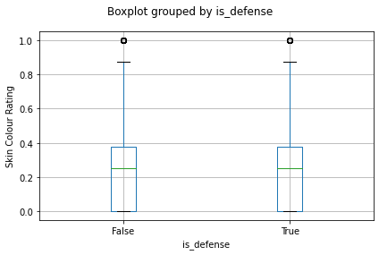

```python
bins = np.arange(-0.125 / 2, 1 + .125, 0.125)

pos_data.boxplot("rating", "is_defense")
plt.title("")
plt.ylabel("Skin Colour Rating")
plt.tight_layout()

print(f"The correlation between rating and defense is: {pos_data.rating.corr(pos_data.is_defense):1.4f}")
```

Additionally, the correlation between skin colour and playing in defense is negligible, as can be seen in the box plot.

### Weight hypothesis

We hypthesise that heavy players are more likely to get red cards.

```python
weight_data = prediction_data.copy()
weight_data_pred = pos_data.drop(["rating"], axis=1)

n_larger_linear, n_larger_regtree = test_data(prediction_data, 19, "weight")

print('Number of greater test errors with shuffled data and linear model: %i' % n_larger_linear)
print('Number of greater test errors with shuffled data and regression tree model: %i' % n_larger_regtree)
```

```
Run shuffleset no 1
Run shuffleset no 2
Run shuffleset no 3
Run shuffleset no 4
Run shuffleset no 5
Run shuffleset no 6
Run shuffleset no 7
Run shuffleset no 8
Run shuffleset no 9
Run shuffleset no 10
Run shuffleset no 11
Run shuffleset no 12
Run shuffleset no 13
Run shuffleset no 14
Run shuffleset no 15
Run shuffleset no 16
Run shuffleset no 17
Run shuffleset no 18
Run shuffleset no 19
Number of greater test errors with shuffled data and linear model: 15
Number of greater test errors with shuffled data and regression tree model: 2
```

This hypothesis cannot be confirmed with high probability.

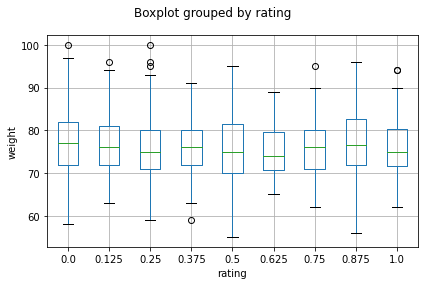

```python
pos_data.boxplot("weight", "rating")
plt.title("")
plt.ylabel("weight")
plt.tight_layout()
```

There is no relation between the rating and the weight.

### Summary

We see that both our alternative hypotheses cannot be supported by the data.